# CHAPTER.13 – Convolutional Neural Networks

Convolution Neural Networks(CNNs)는 뇌의 시각 피질(brain's visual cortex) 연구에서 출현했으며, 1980년대부터 이미지 인식에 사용되어 왔다.

지난 몇 년 동안, 계산 능력 증가, 사용 가능한 학습 데이터의 양, deep nets을 학습하기 위한 트릭으로 인해 CNN은 복잡한 시각적 작업에서 초인적인 성능을 얻을 수 있었다.

CNN은 시각적 인식에 국한되지 않고, *음성인식(voice recongition*)이나 *자연어 처리(NPL;Natural Language Processing)* 와 같은 다른 업무에서도 이용한다.

**13장에서는**

- CNN이 어디에서부터 왔는지
- building blocks이 어떻게 보이는지
- 텐서플로우를 사용해 CNN구현 방법을 설명
- 최고의 CNN 구조 중 일부에 대해 살펴 봄

# Setup

```python
# To support both python 2 and python 3
from __future__ import division, print_function, unicode_literals

# Common imports
import numpy as np
import os

# to make this notebook's output stable across runs
def reset_graph(seed=42):
    tf.reset_default_graph()
    tf.set_random_seed(seed)
    np.random.seed(seed)

# To plot pretty figures
%matplotlib inline
import matplotlib
import matplotlib.pyplot as plt
plt.rcParams['axes.labelsize'] = 14
plt.rcParams['xtick.labelsize'] = 12
plt.rcParams['ytick.labelsize'] = 12

# Where to save the figures
PROJECT_ROOT_DIR = "."
CHAPTER_ID = "cnn"

def save_fig(fig_id, tight_layout=True):
    path = os.path.join(PROJECT_ROOT_DIR, "images", CHAPTER_ID, fig_id + ".png")
    print("Saving figure", fig_id)
    if tight_layout:
        plt.tight_layout()
    plt.savefig(path, format='png', dpi=300)
```

A couple utility functions to plot grayscale and RGB images:

```python
def plot_image(image):
    plt.imshow(image, cmap="gray", interpolation="nearest")
    plt.axis("off")

def plot_color_image(image):
    plt.imshow(image.astype(np.uint8),interpolation="nearest")
    plt.axis("off")
```

And of course we will need TensorFlow:

```python
import tensorflow as tf
```

# 1. The Architecture of the Visual Cortex

David H. Hubel & Torsten Wiesel은 고양이에 대한 일련의 실험을 수행해, 시각 피질의 구조에 대한 결정적인 통찰력을 얻었다.

특히 그들은 시각 피질의 많은 뉴런이 작은 *local receptive field* 를 가지고 있다는 것을 보여주었다.

서로 다른 뉴런의 receptive fields는 겹칠 수 있으며, 저자들은 수평선의 이미지에만 반응하는 뉴런, 방향이 다른 것에 대해서만 반응하는 뉴런을 보여주었다. (2개의 뉴런은 동일한 local receptive fields를 가질 수 있지만, 다른 라인 방향에 반응 할 수 있다.)

또한, 일부 뉴런은 더 큰 receptive fileds를 가지고 있으며, 낮은 수준 패턴들의 조합인 더욱 복잡한 패턴에 반응한다는 것을 발견하였다. -> 이 발견은 높은 수준 뉴런이 인접한 낮은 수준 뉴런의 출력을 기반으로 한다는 아이디어 도출!

이 강력한 구조는 시각적 영역의 모든 영역에서 복잡한 패턴을 감지 할 수 있다.

시각 피질에 대한 연구는 1980년에 도입된 neocognitron에 영감을 주어, 점차적으로 우리가 *Convolutional neural networks(CNN)* 으로 부르는 것으로 발전하였다.

중요한 마일스톤으로는 1998년에, 손글씨로 작성된 번호를 확인하는 데 널리 사용되는 유명한 LeNet-5 아키텍쳐를 도입한 논문이 있다.

이 아키텍쳐는 완전히 연결된 레이어와, sigmoid 활성화 함수와 같이 이미 알고 있는 buliding block이 있지만, 두 개의 새로운 building block인 *convolution layers* 와 *pooling layers* 가 있다.

# 2. Convolutional layer

CNN의 가장 중요한 buliding block은 _convolutional layer_이다.

- 첫 번째 컨볼루션 레이어의 뉴런은 입력 이미지의 모든 단일 픽셀에 연결되지 않고, receptive fields의 픽셀에만 연결된다.
- 두 번째 컨볼루션 레이어의 각 뉴런은 첫 번째 레이어의 작은 사각형 안에 있는 뉴런에만 연결된다.

이 아키텍쳐는 네트워크가 첫 번째 hidden layer의 하위 레벨 feature에 집중하고, 다음 hidden 레이어의 상위 레벨 feature로 어셈블하는 등의 작업을 수행 할 수 있다.

이 작업은 CNN이 이미지 인식을 위해 잘 작동하는 이유 중 하나인 real-world 이미지에서 일반적인 구조이다.

- *zero padding* : 레이어가 이전 레이어와 동일한 높이와 너비를 가지려면, 다이어그램에 표시된 것 처럼 입력 주위에 0을 추가

- *stride* : 두 개의 연속적인 receptive fields 사이의 거리

## 2.1 Filters

뉴런의 가중치는 reseptive fields의 크기와 같은 작은 이미지로 표현 될 수 있다.

그림 13-5는 *filters (컨볼루션 레이어)* 라고 하는 두가지 가능한 가중치 set을 보여준다.

```python
from sklearn.datasets import load_sample_image
china = load_sample_image("china.jpg")
flower = load_sample_image("flower.jpg")
image = china[150:220, 130:250]
height, width, channels = image.shape
image_grayscale = image.mean(axis=2).astype(np.float32)
images = image_grayscale.reshape(1, height, width, 1)
```

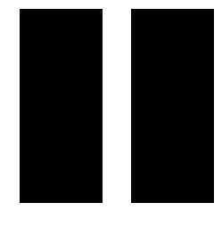

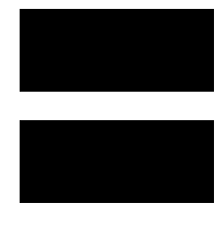

```python
fmap = np.zeros(shape=(7, 7, 1, 2), dtype=np.float32)
fmap[:, 3, 0, 0] = 1
fmap[3, :, 0, 1] = 1
plot_image(fmap[:, :, 0, 0])
plt.show()
plot_image(fmap[:, :, 0, 1])
plt.show()
```

**그림 13-5의 필터**

위 : 중앙의 세로에는 1로 채워지고 나머지는 0으로 채워진 필터

아래 : 중앙의 가로에는 1로 채워지고 나머지는 0으로 채워진 필터

이러한 가중치를 사용하는 뉴런은 가운데 수직, 수평선을 제외한 나머지 receptive fields는 무시한다.

```python
reset_graph()

X = tf.placeholder(tf.float32, shape=(None, height, width, 1))
feature_maps = tf.constant(fmap)
convolution = tf.nn.conv2d(X, feature_maps, strides=[1,1,1,1], padding="SAME")
```

```python
with tf.Session() as sess:
    output = convolution.eval(feed_dict={X: images})
```

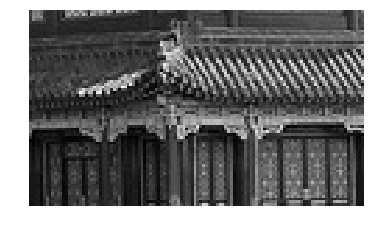

```python
plot_image(images[0, :, :, 0])
plt.show()
```

네트워크에 위 그림과 같이 입력 이미지를 제공하고, 레이어의 모든 뉴런이 동일한 수직선 필터를 사용할 때 레이어는 아래 이미지를 출력.

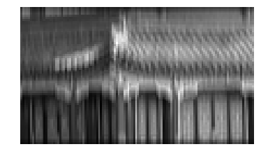

```python
plot_image(output[0, :, :, 0])

plt.show()
```

나머지는 희미해지지만, 수직 흰색 선은 뚜렷해짐.

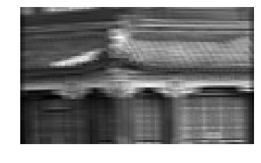

```python
plot_image(output[0, :, :, 1])

plt.show()
```

위 이미지는 모든 뉴런이 수평선 라인 필터를 사용하면 얻을 수 있는 이미지이다.

수평 흰색 선은 뚜렷해지지만, 나머지는 흐려짐.

따라서 동일한 필터를 사용하는 뉴런으로 가득 찬 레이어는 필터와 가장 유사한 이미지 영역을 강조하여 표시하는 *feature map* 을 제공한다.

학습 중 CNN은 작업에 가장 유용한 필터를 찾고, 더 복잡한 패턴으로 결합하는 방법을 학습 한다.

## 2.2 Stacking Multiple Feature Maps

위에서 간단하게 각 filter(컨볼루션 레이어)를 2차원 레이어로 나타냈지만,

실제로는 크기가 동일한 몇 개의 feature map으로 구성되어 보다 정확하게 3차원으로 표현 된다.

뉴런의 recpetive fields는 모든 이전 레이어의 feature map전체로 확장된다.

-> filter(컨볼루션 레이어)는 입력에 여러 필터를 동시에 적용해, 입력의 여러 feature들을 감지 할 수 있다.

**feature map의 모든 뉴런이 동일한 파라미터를 공유한다는 사실은 CNN이 한 위치의 패턴을 인식하면, 다른 위치에서도 패턴을 인식 할 수 있다는 것이다. (일반적인 DNN의 경우 한 위치의 패턴을 인식하면 해당 위치에서만 패턴인식 가능.)**

입력 이미지는 여러 개의 하위 레이어로 구성된다.

일반적으로 RGB(빨강,녹색,파랑)의 3가지가 있다.

greay sclae 이미지에는 채널이 하나지만, 일부 이미지에는 훨씬 더 많은 빛이 있을 수 있다.

주의할 점은 동일한 행과 열에 있지만 서로다른 feature map에 있는 모든 뉴런은 이전 레이어의 동일한 뉴런의 출력에 연결된다.

## 2.3 TensorFlow Implementation

텐서플로에서 각 입력 이미지는 일반적으로 3차원 텐서 **shape [height, width, channels]** 로 표현된다.

- mini-batch 는 4차원 텐서 **shape [mini-batch size, height, width, channels]** 로 표현
- weights of a convolutional layers는 4차원 텐서 **shape [f_h, f_w, f_n', f_n]** 로 표현-
- 컨볼루션 레이어의 bias terms은 단순히 1차원 텐서 **shape [f_n]** 로 표현

아래 코드는 scikit-learn의 `load_sample_images()` 를 사용해 두 개의 샘플 이미지를 로드 (두 가지 색상 이미지를 로드하는데 하나는 중국 사원 중 하나, 다른 하나는 꽃)

그런 다음, 두 개의 7*7 필터를 만듦 (하나는 가운데에 세로 흰색 선, 다른 하나는 가운데에 가로 흰색 선)

텐서플로우의 `tf.nn.conv2d()`를 통해 (zero padding & stride = 2) 컨볼루션 레이어를 사용하여 두 이미지에 적용

마지막으로, 결과 feature map중 하나를 plot

## Simple example

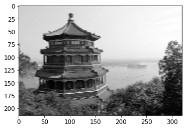

```python
import numpy as np
from sklearn.datasets import load_sample_images

# Load sample images
china = load_sample_image("china.jpg")
flower = load_sample_image("flower.jpg")
dataset = np.array([china, flower], dtype=np.float32)
batch_size, height, width, channels = dataset.shape

# Create 2 filters
filters = np.zeros(shape=(7, 7, channels, 2), dtype=np.float32)
filters[:, 3, :, 0] = 1  # vertical line
filters[3, :, :, 1] = 1  # horizontal line

# Create a graph with input X plus a convolutional layer applying the 2 filters
X = tf.placeholder(tf.float32, shape=(None, height, width, channels))
convolution = tf.nn.conv2d(X, filters, strides=[1,2,2,1], padding="SAME")

with tf.Session() as sess:
    output = sess.run(convolution, feed_dict={X: dataset})

plt.imshow(output[0, :, :, 1], cmap="gray") # plot 1st image's 2nd feature map
plt.show()
```

**convolution = tf.nn.conv2d(X, filters, strides=[1,2,2,1], padding="SAME")에 대한 설명**

- **X** 는 입력 mini-batch
- **filters** 는 적용 할 필터 집합
- **stride** 는 4개의 element의 1차원 배열이며, 중간의 두 개의 요소는 vertical and horizontal strides(s_h, s_w)

  첫 번째와 마지막 요소는 현재 1과 같아야 된다(?).

```python
reset_graph()

X = tf.placeholder(shape=(None, height, width, channels), dtype=tf.float32)
conv = tf.layers.conv2d(X, filters=2, kernel_size=7, strides=[2,2],
                        padding="SAME")
```

```python
init = tf.global_variables_initializer()

with tf.Session() as sess:
    init.run()
    output = sess.run(conv, feed_dict={X: dataset})
```

[figure not shown]

```python
plt.imshow(output[0, :, :, 1], cmap="gray") # plot 1st image's 2nd feature map
plt.show()
```

실제 CNN은 학습 알고리즘이 가장 최적의 필터를 자동으로 찾아준다.

텐서플로우는 tf.layers.conv2d():함수를 사용하여 필터 변수(kernel)을 만들고 이를 무작위로 초기화 할 수 있다.

위의 코드는 2x2 stride 와 **'SAME'** 을 사용해, 2개의 7x7 feature map이 있는 컨볼루션 레이어 다음에 input placeholder를 만든다.

컨볼루션 레이어 파라미터인 filter의 수, height, width, strides, padding type을 선택해야 한다.

cross-validation을 사용해 올바를 파라미터 값을 찾을 수는 있지만, 시간이 많이 걸린다.

따라서 파라미터 값이 실제로 가장 잘 작동하는지에 대한 아이디어를 얻기 위해 일반적인 CNN구조에 대해 뒷 부분에서 다룬다.

## VALID vs SAME padding

```python
reset_graph()

filter_primes = np.array([2., 3., 5., 7., 11., 13.], dtype=np.float32)
x = tf.constant(np.arange(1, 13+1, dtype=np.float32).reshape([1, 1, 13, 1]))
filters = tf.constant(filter_primes.reshape(1, 6, 1, 1))

valid_conv = tf.nn.conv2d(x, filters, strides=[1, 1, 5, 1], padding='VALID')
same_conv = tf.nn.conv2d(x, filters, strides=[1, 1, 5, 1], padding='SAME')

with tf.Session() as sess:
    print("VALID:\n", valid_conv.eval())
    print("SAME:\n", same_conv.eval())
```

```
VALID:
 [[[[ 184.]
   [ 389.]]]]
SAME:
 [[[[ 143.]
   [ 348.]
   [ 204.]]]]
```

```python
print("VALID:")
print(np.array([1,2,3,4,5,6]).T.dot(filter_primes))
print(np.array([6,7,8,9,10,11]).T.dot(filter_primes))
print("SAME:")
print(np.array([0,1,2,3,4,5]).T.dot(filter_primes))
print(np.array([5,6,7,8,9,10]).T.dot(filter_primes))
print(np.array([10,11,12,13,0,0]).T.dot(filter_primes))
```

```
VALID:
184.0
389.0
SAME:
143.0
348.0
204.0
```

## 2.4 Memory Requirements

CNN의 문제점으로는 역전파의 역방향패스가 순방향패스동안 계산 된 모든 intermediate값을 필요로 하기 때문에 방대한 양의 RAM 필요

*예를 들어, stride=1과 SAME padding을 사용해*

*크기가 150x100 인 featrue maps 200개를 출력하고*

*5x 5 필터가 있는 컨볼루션 레이어를 생각해보자!*

*입력이 150 x 100 RGB(3개 채널)인 경우, 파라미터 수는(5 x 5 x 3 + 1) x 200 = 15,200(+1은 bias term)가 됨*

*-> 이는 fully connected layer와 비교하면 다소 작음*

*하지만, 200개의 각 feature map은 150x100개의 뉴런이 포함되어 있으며, 각 뉴런은 5 x 5 x 3 = 75개의 입력에 대해 weight sum을 계산 해야 함*

*-> 총 225,000,000개의 부동 소수점 곱셈이 필요*

*fully connectec layer만큼 나쁘지는 않지만, 여전히 계산을 많이 해야 함.*

*또한, feature map이 32 bit float을 사용하여 표현 되는 경우, 컨볼루션 레이어의 출력은 200 x 150 x 100 x 32 = 9600만 비트(약 11.4MB)의 RAM을 차지함.*

*학습 batch에 100개의 인스턴스가 포함되어 있는 경우, 이 레이어는 1GB이상의 RAM을 사용하게 됨*

추론하는 동안(새로운 인스턴스에 대한 예측을 할 때) 한 레이어가 차지하는 RAM은 다음 레이어가 계산 되자마자 날려 보낼 수 있으므로, 두 개의 연속 된 레이어에 필요한 만큼의 RAM이 필요하다.

하지만 학습 중에는 순방향 패스 중에 계산되는 모든 것이 역 전파를 위해 보존되어야 하므로, 필요한 RAM의 양은 적어도 모든 레이어에서 필요한 총 RAM용량이다!!

**TIP** 메모리 부족 오류로 인해 학습에 문제가 있다면 아래의 여러가지 방법이 있다.

1. mini-batch size를 줄여보는 방법
2. stride를 사용해, dimensinality를 줄이거나, 몇 개의 레이어를 제거하는 방법
3. 32-bit-floats 대신 16-bit-floats를 사용
4. 여러 장치에 CNN을 배포하는 방법

이제 CNN의 second common building block인 *pooling layer* 에 대해 살펴보자!

# 3. Pooling layer

컨볼루션 레이어가 작동하는 방식을 이해하면, pooling layer을 이해하기 쉽다.

목표는 계산 부하(computational load), 메모리 사용, 파라미터의 수를 줄이기 위해 입력 이미지를 *subsample*(shrink)하는 것이다. 입력 이미지를 _subsample_하면 overfitting 위험에 제한을 준다.

컨볼루션 레이어와 마찬가지로

pooling layer의 각 뉴런은 small rectangular receptive field내에 있는 이전 레이어의 제한된 수의 뉴런의 output에 연결 된다.

이전과 마찬가지로, size, stride, padding type을 정의해야 하는데, pooling 뉴런에는 weight가 없다.

따라서 모든 작업은 최대 값 또는 평균 값과 같은 aggregation function 을 사용해 입력 값에 대해 집계한다.

오직 각 커널의 최대 입력 값만이 다음 레이어로 넘어가고 다름 입력들은 삭제된다.

이는 분명 매우 파괴적인 종류의 레이어이다.

: 작은 2*2 커널과 stride=2에서도 출력은 양방향으로 2배 더 작음 (영역은 4배 작아짐) -> 입력 값의 75%가 drop

pooling layer는 일반적으로 모든 input channel에 독립적으로 동작하기 때문에, output depth는 input depth와 동일

이미지의 spatial dimension(height, width)는 변경되지 않지만, 채널 수가 줄어들 경우 depth dimension을 넘을 수 있다.

텐서플로우에서, max pooling layer를 구현하는 것은 매우 easy!

아래 코드는 2*2커널, stride=2, no padding 을 사용해 max pooling layer를 만든 다음, 데이터 셋의 모든 이미지에 적용

```python
#load the image dataset, just like above

batch_size, height, width, channels = dataset.shape

filters = np.zeros(shape=(7, 7, channels, 2), dtype=np.float32)
filters[:, 3, :, 0] = 1  # vertical line
filters[3, :, :, 1] = 1  # horizontal line
```

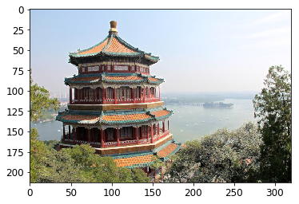

```python
# 입력 X에 max pooling layer를 가지는 그래프를 만듦
X = tf.placeholder(tf.float32, shape=(None, height, width, channels))
max_pool = tf.nn.max_pool(X, ksize=[1,2,2,1], strides=[1,2,2,1],padding="VALID")

# ksize는 입력 텐서의 4차원 모두를 따르는 커널 shape를 포함:[batch size, height, width, channels]
with tf.Session() as sess:
    output = sess.run(max_pool, feed_dict={X: dataset})

plt.imshow(output[0].astype(np.uint8))  # plot the output for the 1st image
plt.show()
```

[figure not shown]

[figure not shown]

```python
plot_color_image(dataset[0])
plt.show()

plot_color_image(output[0])
plt.show()
```

# 4. CNN Architectures

일반적인 CNN 아키텍쳐는 몇 개의 convolutional layers (일반적으로 각각 하나는 ReLU), pooling layer, 그리고 다른 몇 개의 convolutional layer(+ReLU), 그다음 pooling layer 등을 쌓음

스택의 상단에는 몇 개의 fully connected layer(+ReLUs)로 구성된 regular feedforward neural network가 추가되고 최종 레이어에는 예측(ex.예상되는 클래스의 확률을 계산하는 softmax layer) 을 출력한다.

- 흔한 실수는 너무 큰 convolution kernel을 사용하는 것

수 년에 걸쳐 이 기본 아키텍처의 변형이 개발되어 놀라운 발전을 이루었다.

먼저 LeNet-5아키텍쳐(1998)에 대해 본 후, 3개의 ILSVRC 수상을 했던 AlexNet(2012), GoogLeNet(2014), ResNet(2015)에 대해 살펴보자!

## 4.1 LeNet-5

LeNet-5 아키텍쳐 ; 가장 널리 알려진 CNN 아키텍쳐

1998년 Yann LeCun에 의해 만들어졌으며, 손으로 쓴 숫자 인식(MNIST)에 널리 사용

- MNIST 이미지는 28**28* 픽셀이지만, 32*32 픽셀로 zero padding이 되고, 네트워크에 fed되기 전 정규화
- average pooling layer는 평소보다 약간 더 복잡

  각 뉴런은 입력의 평균을 계산한 다음, 결과를 학습 가능한 coefficient로 곱하고, 학습 할 수 있는 bias term을 추가 한 다음 활성화 함수에 적용
- C3 map에서 대부분의 뉴런은 3개 또는 4개의 S2 map의 뉴련과 연결
- output layer : input과 weight벡터의 내적을 계산하는 대신, 각 뉴런은 input 벡터와 weight 벡터 사이의 Euclidian 거리의 제곱을 출력

  각 출력은 이미지가 특정 숫자 클래스에 속하는 정도를 측정

  cross entropy cost function은 잘못 예측한 것에 더 많은 패널티를 부여, 더 큰 gradient를 생성하기 때문에 더 빠르게 수렴

## 4.2 AlexNet

AlexNet CNN 아키텍쳐는 2012년 ImageNet ILSVRC Challenge에서 큰 차이를 보임

; 17%의 top-5 error rate을 달성

```
-> LeNet-5와 매우 유사하지만 더 크고 더 깊음

각각의 컨볼루션 레이어 위에 pooling 레이어를 쌓는 대신에 서로의 위에 직접 컨볼루션 레이어를 쌓음
```

overfitting을 줄이기 위해,

1. 학습 도중 F8과 F9 레이어의 출력에 dropout(50% dropout rate 사용)을 적용
2. 다양한 offset으로 학습 이미지를 무작위로 이동(shifting), 뒤집기(flipping), lighting 조건을 변경해 데이터를 확대

Alexnet은 또한 *local response normalization* 이라고 하는 레이어 C1과 C3의 ReLU단계 직후 competitive noramalization을 이용

이러한 형태의 정규화는 동일한 위치에서 뉴런을 가장 강력하게 활성화 시키는 뉴런을 만듦

```
-> 이렇게 하면, 다양한 feature map을 특수화하고, 이를 분리해 더 광범위한 feature를 타색

-> 궁극적으로 generalization을 향상시킬 수 있음!
```

예를 들어 r=2이고 뉴런이 strong activation을 갖는 경우, 자신이 위와 아래의 feature map에 있는 뉴런의 activation을 억제

AlexNet에서 파라미터는 다음과 같이 설정됨 : r=2, $\alpha$=0.00002, beta=0.75, k=1

`tf.nn.local_response_noramlization()`함수를 사용하여 구현

## 4.3 GoogLeNet

GoogLeNet 아키텍쳐는 Google Research Christian Szegedy 등에 의해 개발 됨

GoogLeNet이 이전 아키텍쳐 보다 훨씬 효율적으로 파라미터를 사용할 수 있도록 하는 *inception modules* 이라는 sub-network에 의해 가능 : GoogLeNet은 실제적으로 AlexNet보다 10배 적은 파라미터를 사용

표기법 3X3+2(S)은 layer가 3X3커널, stride=2, SAME padding을 사용함을 의미

입력 신호(input signal)는 먼저 복사되어 네 개의 다른 레이어로 공급

모든 컨볼루션 레이어는 ReLU activation 함수를 사용

두 번째 컨볼루션 레이어 집합은 서로 다른 커널 크기 (1x1,3x3,5x5)를 사용하므로, 서로 다른 크기로 패턴을 캡처

또한 모든 단일 레이어는 stride=1, SAME을 사용하므로, output의 height와 width가 input과 동일

```
-> final _depth concat layer_에서 depth dimension을 따라 모든 output을 연결하는 것을 가능하게 함
```

이 concatenation layer는 텐서플로우에서 `tf.concat()` operation과 `axis=3`을 사용해 쉽게 구현 가능

1*1 커널을 가진 레이어는 두 가지 용도로 사용 됨

1. 입력보다 훨씬 적은 수의 feature map을 출력하도록 구성되므로, 병목현상이 발생해 차원수가 저하됨 -> 3X3, 5X5 컨볼루션 이젠에 유용! -> 계산함에 있어 expensive한 레이어이기 때문
2. [1X1, 3X3]과 [1X1, 5X5]의 각 쌍은 보다 복잡한 패턴을 캡처할 수 있는 단일의 강력한 컨볼루션 레이어와 같은 역할을 함 -> 이 컨볼루션 레이어 쌍은 이미지 전체에 걸쳐 two-layer 신경망을 sweep

In short, 전체 inception module을 steroids의 컨볼루션 레이어로 생각할 수 았다.

## 4.4 ResNet

; 152 레이어로 구성된 매우 깊은 CNN사용

-> *skip connections* 을 사용해 학습이 가능했음 : 레이어로 전달되는 신호는 스택보다 약간 높은 위치에 있는 레이어의 output에도 추가됨

신경망을 학습할 때, 모델을 목표함수 h(x)로 만드는 것이 목표!

입력 x를 네트워크의 풀력에 추가하면, 네트워크는 h(x)대신 f(x)=h(x)-x를 강제로 모델링 함

-> *residual learning* 이라고 함!

일반적인 신경망을 초기화 할 때, 그 가중치는 0에 가깝기 때문에 네트워크는 0에 가까운 값을 출력함

skip connection을 추가하면, resulting network는 입력의 copy를 출력

-> 이는 초기에 identity function을 모델링

목표 함수가 identity function에 상당히 가깝다면, 학습을 상당히 가속화 할 것!

skip connection 덕분에, 신호가 전체 네트워크에 쉽게 전달 될 수 있다.

deep residual network는 *residual units* 의 스택으로 볼 수 있다.

(residual unit은 skip connection을 가진 작은 신경망)

이제 ResNet의 아키텍쳐를 보자!

GoogLeNet과 완전하게 동일하게 시작하고 끝나며, 중간에 심플한 residual units의 스택이 쌓여 있음

각각의 residual unit은 3*3 커널을 사용, spatial cimensions(stride 1, SAME padding)을 유지하면서, 두 개의 컨볼루션 레이어로 구성

feature map 의 개수는 몇 개의 residual units이 있을 때마다 두 배가 되며, 동시에 높이와 너비가 반으로 줄어든다

-> 이 경우, 입력은 동일한 모양을 가지지 않으므로, 나머지 residual unit의 출력에 직접 추가 될 수 없다!

이 문제를 해결하기 위해 입력은 stride 2의 1*1 컨볼루션 레이어와 올바른 feature map의 수를 통과